# Time Series Analysis of United Kingdom Economic Data

Mark Preston

October 17, 2018

## Using ARIMA and Regression to Evaluate UK GDP and Unemployment data

### Introduction: Loading data and introducing the analysis

As always, I’ll start by loading the necessary packages and data. For this analysis, I’m going to assess UK GDP and Unemployment levels for a given time period.

```r
library(tidyverse)
library(tseries)
library(forecast)
library(ggfortify)

theme_set(
  theme_minimal()
)

uk_econ <- read.csv("Unemployment_GDP_UK.csv", stringsAsFactors = F) %>%
  rename(Year = "ï..Year")
```

### Exploratory analysis and modelling set-up

To start, I’m doing a basic summary for the data. As seen, the data spans from 1955-1969 through all four quarters.

```r
summary(uk_econ)
```

```
##       Year         Quarter           UN             GDP
##  Min.   :1955   Min.   :1.00   Min.   :199.0   Min.   : 81.37
##  1st Qu.:1958   1st Qu.:1.75   1st Qu.:294.5   1st Qu.: 85.17
##  Median :1962   Median :2.50   Median :360.5   Median : 96.28
##  Mean   :1962   Mean   :2.50   Mean   :380.2   Mean   : 98.49
##  3rd Qu.:1966   3rd Qu.:3.25   3rd Qu.:468.0   3rd Qu.:110.20
##  Max.   :1969   Max.   :4.00   Max.   :547.0   Max.   :119.60
```

I was interested in seeing how each set of values change over time so I visualized both in a faceted line plot. GDP has a slight, positive trend up over the sample. UN also shows a positive trend but, is also coupled with what appears to be a cyclical aspect. Both would appear to be time dependent here so my guess would be they are each non-stationary series but, I’ll work to review this.

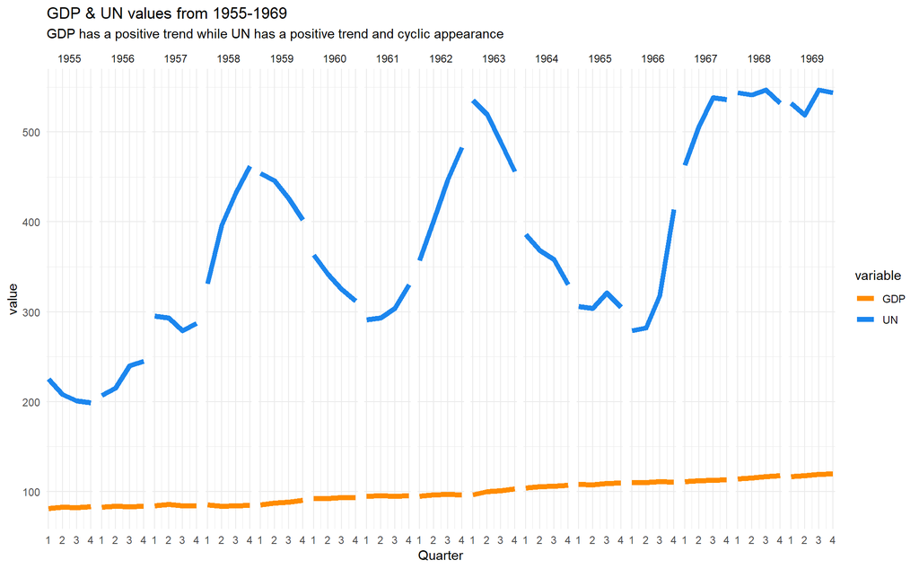

```r
uk_econ %>%
  gather(key = "variable", value = "value", -Year, -Quarter) %>%
  ggplot(aes(Quarter, value, colour = variable)) +
  geom_line(size = 2) +
  facet_wrap(facets = "Year", nrow = 1) +
  scale_colour_manual(values = c("darkorange", "dodgerblue2")) +
  labs(title = "GDP & UN values from 1955-1969",
       subtitle = "GDP has a positive trend while UN has a positive trend and cyclic appearance")
```

The previous visualization utilizes a regular data frame but, the object can be converted to time series. This assists with any visualization and also renders an object that can be used in the modelling phase. Given this, I’m making a time series object to use going forward.

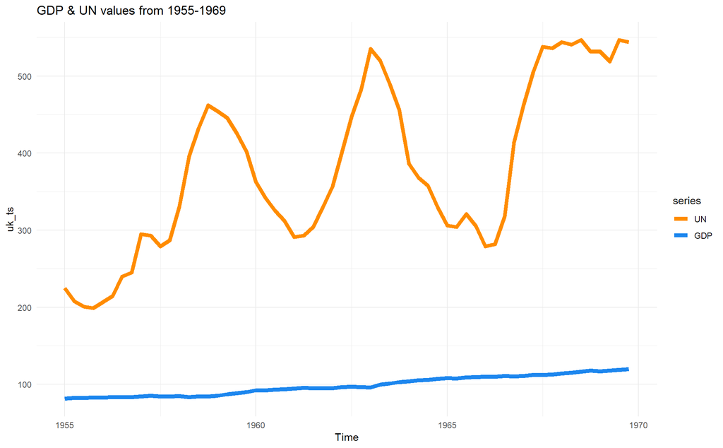

```r
uk_ts <- uk_econ %>%
  select(-Year, -Quarter) %>%
  ts(frequency = 4, start = c(1955, 1), end = c(1969, 4))

autoplot(uk_ts) +
  geom_line(size = 2) +
  scale_colour_manual(values = c("darkorange", "dodgerblue2")) +
  ggtitle("GDP & UN values from 1955-1969")
```

Prior to the time series modelling, I’m making the training and test set. For this analysis, I’ll be forecasting each quarter for 1969; the remainder of the set will be used to train the models.

```r
uk_train <- window(uk_ts, end = c(1968, 4))

uk_test <- window(uk_ts, start = c(1969, 1))
```

### Forecasting GDP

Before getting into model development, I have to select the appropriate forecasting method. The two options here are ARMA (autoregressive moving average) and ARIMA (autoregressive integrated moving average). One of the necessary conditions for ARMA models is having stationary data. The initial visualization seemed to show non-stationary data for both GDP and UN but, I’ll check this using an Automated Dickey-Fuller test. The results show a high p-value, which confirms the data is non-stationary.

```r
adf.test(uk_econ$GDP)
```

```
##
##  Augmented Dickey-Fuller Test
##
## data:  uk_econ$GDP
## Dickey-Fuller = -3.1159, Lag order = 3, p-value = 0.1237
## alternative hypothesis: stationary
```

With this in mind, I’m going to develop an ARIMA model.

#### ARIMA Values

- P is the order of the autoregressive component: 0
- D is the degree of first differencing involved: 1 (given non-stationarity)
- Q is the order of the moving average component: 0

```r
(gdp_arima <- auto.arima(uk_train[,"GDP"],
                         seasonal = F,
                         stepwise = F,
                         approximation = F))
```

```
## Series: uk_train[, "GDP"]
## ARIMA(0,1,0) with drift
##
## Coefficients:
##        drift
##       0.6624
## s.e.  0.1152
##
## sigma^2 estimated as 0.743:  log likelihood=-69.36
## AIC=142.73   AICc=142.96   BIC=146.74
```

With the model constructed, I’m going to review how the forecast values compare to the actuals. As the plot shows, the fitted values look fairly congruent with the actuals. This is a good sign that the ARIMA model does a reasonable job forecasting GDP.

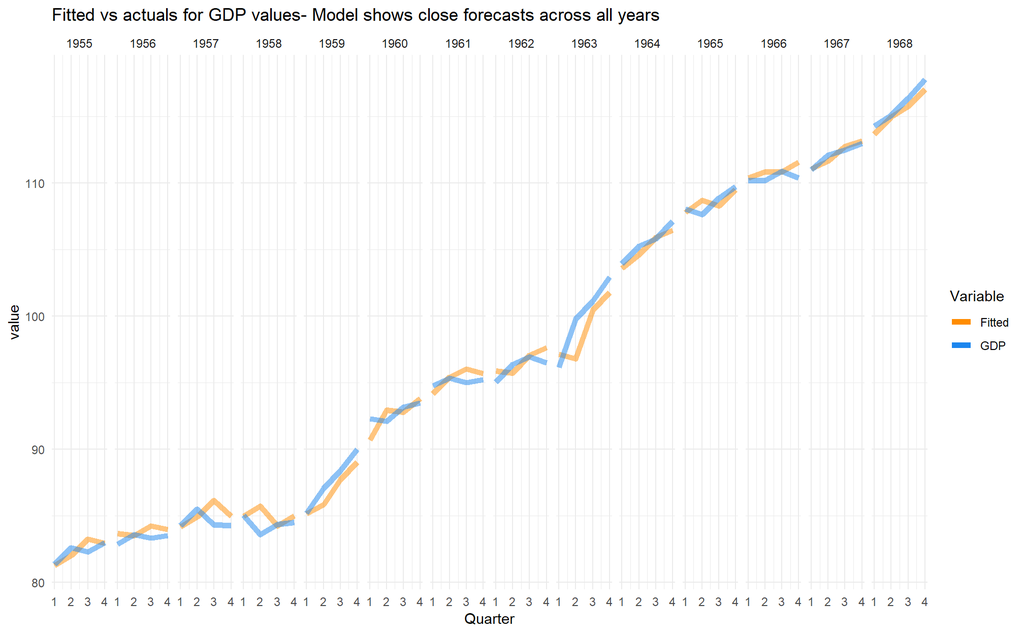

```r
uk_econ %>%
  slice(-57:-60) %>%
  select(Year, Quarter, GDP) %>%
  mutate(Fitted = gdp_arima$fitted) %>%
  gather(key = "Variable", value = "value", -Year, -Quarter) %>%
  ggplot(aes(Quarter, value, colour = Variable)) +
  geom_line(size = 2, alpha = .5) +
  facet_wrap(facets = "Year", nrow = 1) +
  scale_colour_manual(values = c("darkorange", "dodgerblue2")) +
  guides(colour = guide_legend(override.aes = list(alpha = 1))) +
  ggtitle("Fitted vs actuals for GDP values- Model shows close forecasts across all years")
```

As with any model, it’s essential to review the residuals. The residuals look very small across time, which is expected given the previous plot showing such close fitted and actuals. The residual ACF shows no significant autocorrelations, although some of the lags are on the border. The residuals histogram looks broadly normal as well. Finally, the Ljung-Box test shows a high p-value which provides a formal statistical test to show there is no significant autocorrelation.

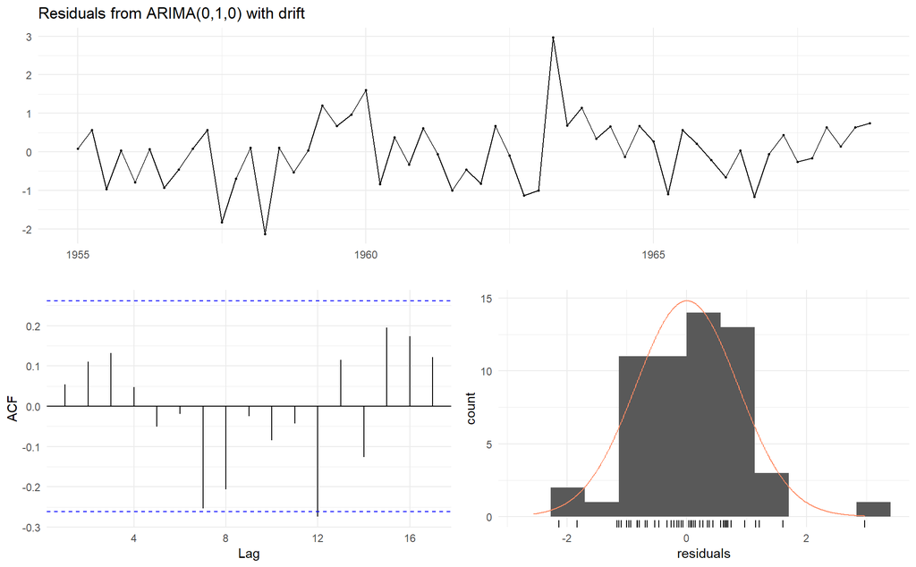

```
##
##  Ljung-Box test
##
## data:  Residuals from ARIMA(0,1,0) with drift
## Q* = 9.4445, df = 7, p-value = 0.2223
##
## Model df: 1.   Total lags used: 8
```

```r
checkresiduals(gdp_arima)
```

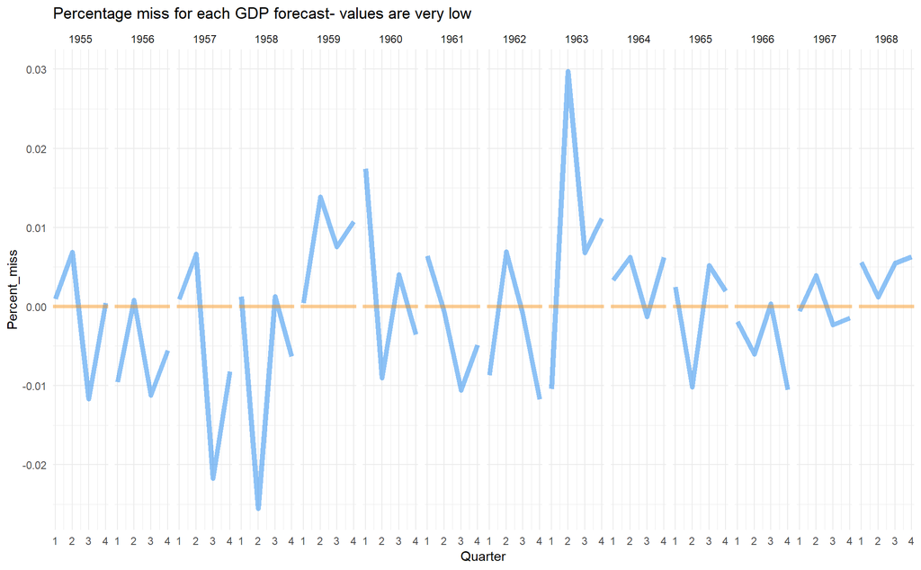

```r
uk_econ %>%
  slice(-57:-60) %>%
  mutate(fitted = gdp_arima$fitted,
         Percent_miss = (GDP - fitted) / GDP) %>%
  ggplot(aes(Quarter, Percent_miss)) +
  geom_line(size = 2, alpha = .5, colour = "dodgerblue2") +
  geom_hline(yintercept = 0, size = 1.5, alpha = .4, colour = "darkorange") +
  facet_wrap(facets = "Year", nrow = 1) +
  ggtitle("Percentage miss for each GDP forecast- values are very low")
```

The mean squared error (MSE) and root mean squared error (RMSE) can also be found below; they both show a very close fit. The total sum of squares erorr total (SSE) seems quite low here as well.

```r
c(sum_sq_error = sum(gdp_arima$residuals ^ 2),
  mean_sq_error = mean(gdp_arima$residuals ^ 2),
  RMSE = sqrt(mean(gdp_arima$residuals ^ 2)))
```

```
##  sum_sq_error mean_sq_error          RMSE
##    40.1229064     0.7164805     0.8464517
```

Looking forward, I’ve developed a forecast for all four quarters in 1969. The forecast follows the trend and show GDP rising for that year.

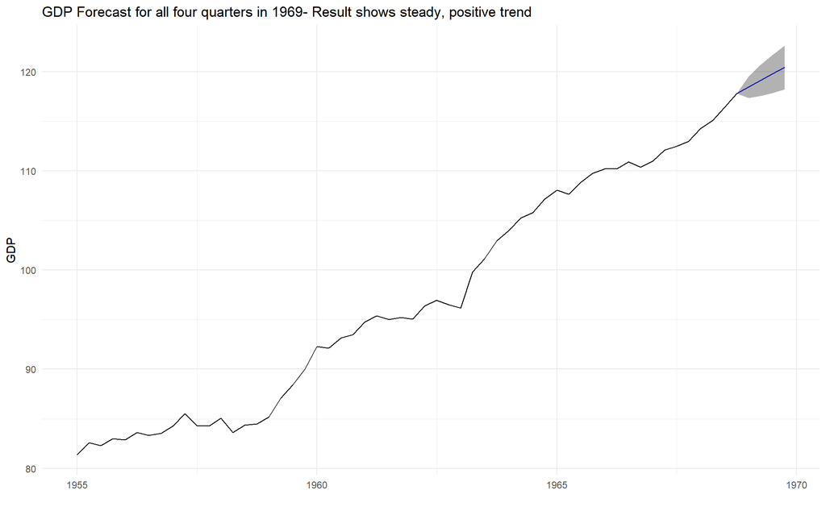

```r
autoplot(forecast(gdp_arima, h = 4)) +
  labs(title = "GDP Forecast for all four quarters in 1969- Result shows steady, positive trend",
       y = "GDP")
```

```r
accuracy(forecast(gdp_arima, h = 4), uk_test[,"GDP"])
```

```
##                        ME      RMSE       MAE         MPE      MAPE
## Training set  0.001441207 0.8464517 0.6381945 -0.02097366 0.6730658
## Test set     -1.155909091 1.2103140 1.1559091 -0.97987000 0.9798700
##                   MASE       ACF1 Theil's U
## Training set 0.2402527 0.05442436        NA
## Test set     0.4351500 0.26461785  1.052318
```

### Forecasting unemployment numbers (UN)

I’ll follow the same routine as I did for GDP for UN. This starts with checking stationarity to determine if I should use ARMA or ARIMA. As seen, the high p-value indicates the series is non-stationary, which means it needs to be differenced. ARIMA will be used as a result.

```r
adf.test(uk_econ$UN)
```

```
##
##  Augmented Dickey-Fuller Test
##
## data:  uk_econ$UN
## Dickey-Fuller = -3.1896, Lag order = 3, p-value = 0.09763
## alternative hypothesis: stationary
```

#### ARIMA Values

- P is the order of the autoregressive component: 1
- D is the degree of first differencing involved: 1 (given non-stationarity)
- Q is the order of the moving average component: 0

```r
(un_arima <- auto.arima(uk_train[,"UN"],
                        seasonal = F,
                        stepwise = F,
                        approximation = F))
```

```
## Series: uk_train[, "UN"]
## ARIMA(1,1,0)
##
## Coefficients:
##          ar1
##       0.6666
## s.e.  0.0977
##
## sigma^2 estimated as 525.1:  log likelihood=-250.08
## AIC=504.15   AICc=504.39   BIC=508.17
```

As with before, I’m reviewing how close the fitted and actual values appear. Again, the model seems to do a good job forecasting the unemployment values. There are a few years where they appear less close (1957 for instance) but, overall they look fine.

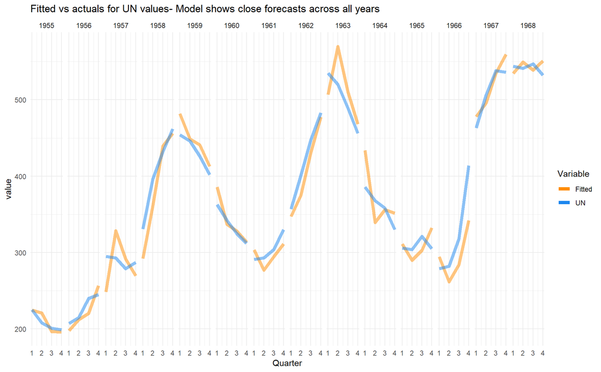

```r
uk_econ %>%
  slice(-57:-60) %>%
  select(Year, Quarter, UN) %>%
  mutate(Fitted = un_arima$fitted) %>%
  gather(key = "Variable", value = "value", -Year, -Quarter) %>%
  ggplot(aes(Quarter, value, colour = Variable)) +
  geom_line(size = 2, alpha = .5) +
  facet_wrap(facets = "Year", nrow = 1) +
  scale_colour_manual(values = c("darkorange", "dodgerblue2")) +
  guides(colour = guide_legend(override.aes = list(alpha = 1))) +
  ggtitle("Fitted vs actuals for UN values- Model shows close forecasts across all years")
```

All the residual plots show normal, non-significantly autocorrelated residuals. The Ljung-Box test output confirms this with a high p-value, which signals that there is no significant autocorrelation.

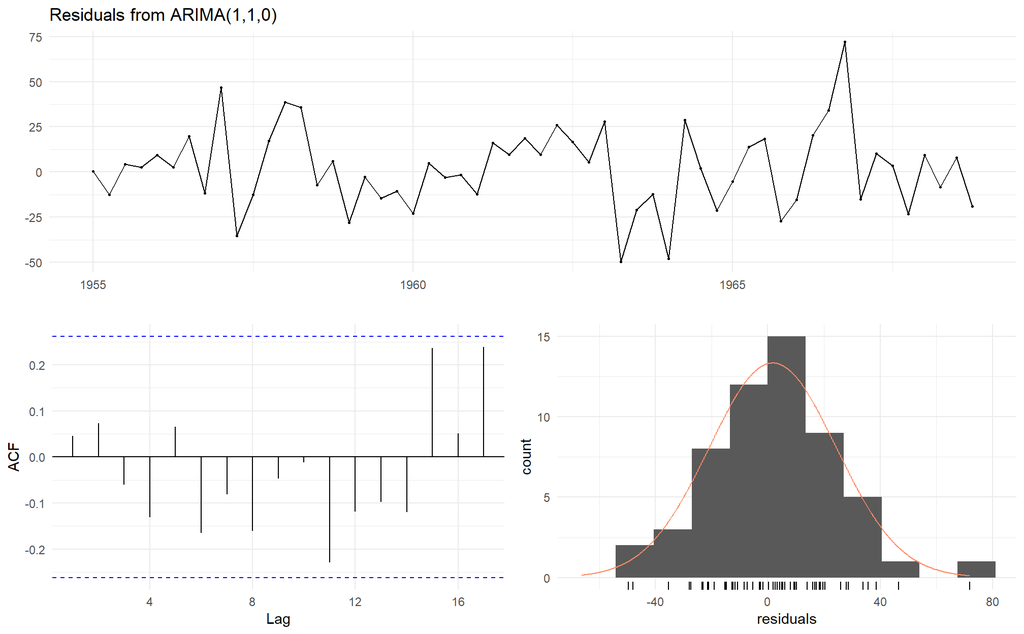

```
##
##  Ljung-Box test
##
## data:  Residuals from ARIMA(1,1,0)
## Q* = 5.9835, df = 7, p-value = 0.5417
##
## Model df: 1.   Total lags used: 8
```

```r
checkresiduals(un_arima)
```

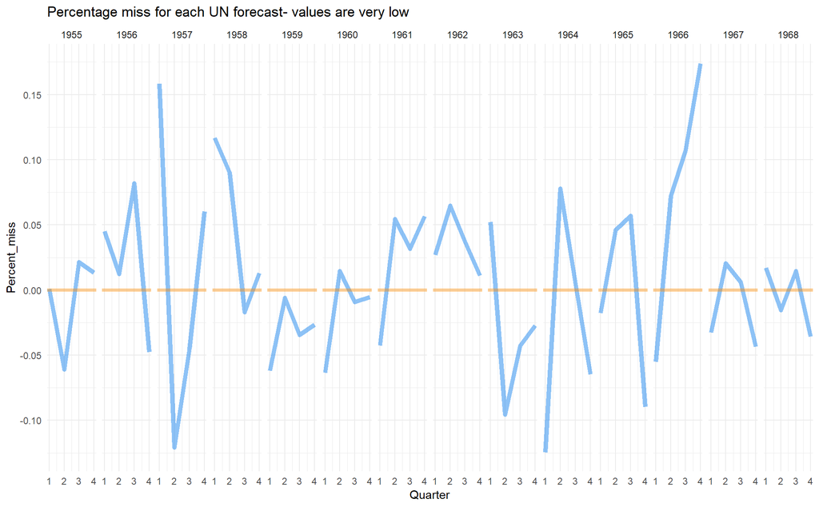

```r
uk_econ %>%
  slice(-57:-60) %>%
  mutate(fitted = un_arima$fitted,
         Percent_miss = (UN - fitted) / UN) %>%
  ggplot(aes(Quarter, Percent_miss)) +
  geom_line(size = 2, alpha = .5, colour = "dodgerblue2") +
  geom_hline(yintercept = 0, size = 1.5, alpha = .4, colour = "darkorange") +
  facet_wrap(facets = "Year", nrow = 1) +
  scale_y_continuous(breaks = seq(-1, 1, .05)) +
  ggtitle("Percentage miss for each UN forecast- values are very low")
```

Again, the accuracy metrics are useful for getting a clear picture of how close the forecasts are. Below, the MSE and RMSE indicate relatively small misses by the ARIMA model. The SSE here is large though, which likely indictaes there are some notable outlier points that are very different from actual to forecast.

```r
c(sum_sq_error = sum(un_arima$residuals ^ 2),
  mean_sq_error = mean(un_arima$residuals ^ 2),
  RMSE = sqrt(mean(un_arima$residuals ^ 2)))
```

```
##  sum_sq_error mean_sq_error          RMSE
##   28353.09078     506.30519      22.50123
```

The forward looking portion shows that the forecast is a decreasing unemployment number for 1969.

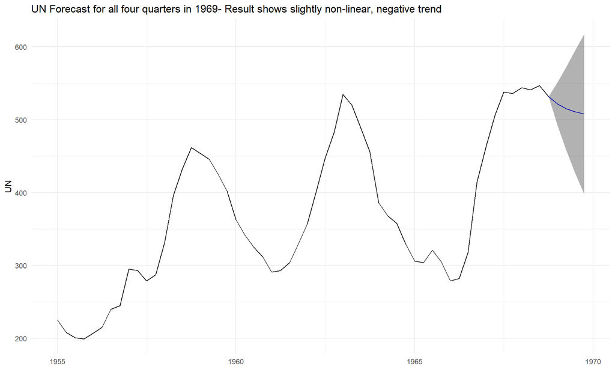

```r
autoplot(forecast(un_arima, h = 4)) +
    labs(title = "UN Forecast for all four quarters in 1969- Result shows slightly non-linear, negative trend",
       y = "UN")
```

This forecast yields a mean absolute percentage error (MAPE) of about 4%. While the accuracy metrics are not decrease substantially from train to test, the mean error does rise by a large amount. Again, I don’t have any baseline for comparison but, this seems like a good forecast given how varied the numbers are.

```r
accuracy(forecast(un_arima, h = 4), uk_test[,"UN"])
```

```
##                     ME     RMSE      MAE       MPE     MAPE      MASE
## Training set  1.730281 22.50123 17.50413 0.6750518 4.903581 0.2142186
## Test set     21.461706 26.06971 21.46171 3.9545456 3.954546 0.2626521
##                    ACF1 Theil's U
## Training set 0.04532975        NA
## Test set     0.17956457   1.61584
```

Given the jump in mean error (ME), I wanted to review each quarterly forecast. It appears that the Q3 and Q4 results are divergent from the actuals creating the large ME increase. Here, the unemployment numbers were higher than forecasted.

```r
data.frame(forecast = forecast(un_arima, h = 4)$mean,
  actual = uk_test[,1])
```

```
##   forecast actual
## 1 522.0004    532
## 2 515.3343    519
## 3 510.8904    547
## 4 507.9280    544
```

### Predicting GDP using linear regression

So far, I’ve been using time series modelling to forecast GDP and unemployment numbers. However, linear regression can also be used. In this section, I’ll use this method to predict GDP. This will be done using a simple OLS model with only one predictor (UN).

As another note though, the upward trend is visible in the plot, so the result does seem plausible in this case.

```r
lm_train <- uk_econ %>%
  filter(Year != 1969)

lm_test <- uk_econ %>%
  filter(Year == 1969)

gdp_lm <- lm(GDP ~ UN, data = lm_train)

summary(gdp_lm)
```

```
##
## Call:
## lm(formula = GDP ~ UN, data = lm_train)
##
## Residuals:
##     Min      1Q  Median      3Q     Max
## -18.024  -7.146  -1.932   8.024  18.411
##
## Coefficients:
##             Estimate Std. Error t value Pr(>|t|)
## (Intercept) 75.42255    4.87117  15.483  < 2e-16 ***
## UN           0.05866    0.01271   4.616 2.45e-05 ***
## ---
## Signif. codes:  0 '***' 0.001 '**' 0.01 '*' 0.05 '.' 0.1 ' ' 1
##
## Residual standard error: 9.84 on 54 degrees of freedom
## Multiple R-squared:  0.283,  Adjusted R-squared:  0.2697
## F-statistic: 21.31 on 1 and 54 DF,  p-value: 2.453e-05
```

Not surprisingly, the linear model shows a poor fit when looking at the actuals and fitted values. The fitted values aren’t really close in any year with the exception of 1961. Otherwise, the value are divergent.

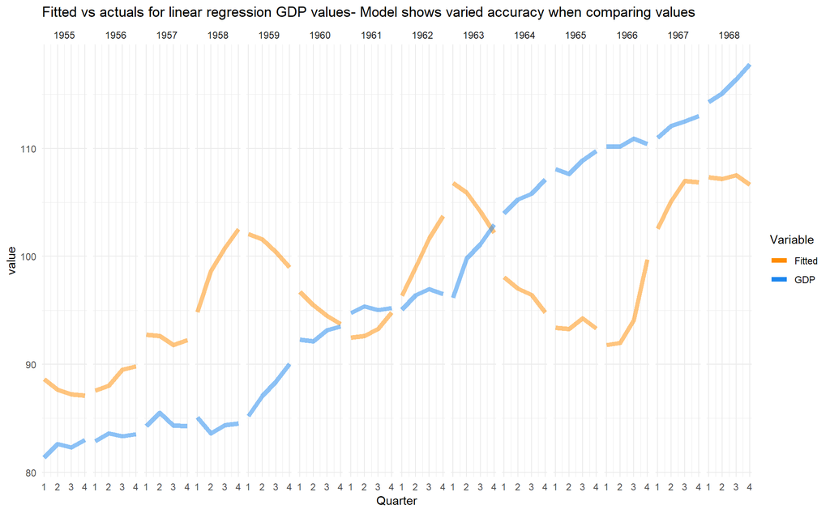

```r
lm_train %>%
  select(Year, Quarter, GDP) %>%
  mutate(Fitted = gdp_lm$fitted) %>%
  gather(key = "Variable", value = "value", -Year, -Quarter) %>%
  ggplot(aes(Quarter, value, colour = Variable)) +
  geom_line(size = 2, alpha = .5) +
  facet_wrap(facets = "Year", nrow = 1) +
  scale_colour_manual(values = c("darkorange", "dodgerblue2")) +
  guides(colour = guide_legend(override.aes = list(alpha = 1))) +
  ggtitle("Fitted vs actuals for linear regression GDP values- Model shows varied accuracy when comparing values")
```

With this in mind, I was expecting high prediction percentage misses, which is clear when looking at the plot below. Comparatively, this model does a much worse job forecasting the 1969 GDP levels than the ARIMA model. Again, I expected this given the ARIMA model includes more information to forecast on and is specifically designed for time series data. Here, the linear model only includes one predictor.

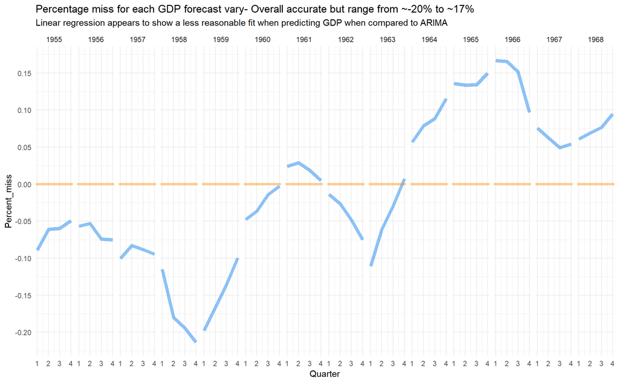

```r
lm_train %>%
  mutate(fitted = gdp_lm$fitted,
         Percent_miss = (GDP - fitted) / GDP) %>%
  ggplot(aes(Quarter, Percent_miss)) +
  geom_line(size = 2, alpha = .5, colour = "dodgerblue2") +
  geom_hline(yintercept = 0, size = 1.5, alpha = .4, colour = "darkorange") +
  facet_wrap(facets = "Year", nrow = 1) +
  scale_y_continuous(breaks = seq(-1, 1, .05)) +
  labs(title = "Percentage miss for each GDP forecast vary- Overall accurate but range from ~-20% to ~17%",
       subtitle = "Linear regression appears to show a less reasonable fit when predicting GDP when compared to ARIMA")
```

Following up the plot, I’ve put together the final prediction for 1969. The percentage misses appear consistent with the training values and range from about 8.7% to about 10.26%.

```r
(gdp_test <- lm_test %>%
  select(-UN) %>%
  mutate(prediction = predict(gdp_lm, lm_test),
         residual = GDP - prediction,
         percent_miss = round(residual / GDP, 3)))
```

```
##   Year Quarter   GDP prediction residual percent_miss
## 1 1969       1 116.8   106.6305 10.16947        0.087
## 2 1969       2 117.8   105.8679 11.93207        0.101
## 3 1969       3 119.0   107.5105 11.48954        0.097
## 4 1969       4 119.6   107.3345 12.26553        0.103
```

```r
c(Train_SSE = sum(gdp_lm$residuals ^ 2),
  Train_MSE = mean(gdp_lm$residuals ^ 2),
  Train_RMSE = sqrt(mean(gdp_lm$residuals ^ 2)),
  Test_SSE = sum(gdp_lm$residuals ^ 2),
  Test_MSE = mean(gdp_test$residual ^ 2),
  Test_RMSE = sqrt(mean(gdp_test$residual ^ 2)))
```

```
##   Train_SSE   Train_MSE  Train_RMSE    Test_SSE    Test_MSE   Test_RMSE
## 5228.641871   93.368605    9.662743 5228.641871  132.061226   11.491790
```

### Predicting Unemployment using linear regression

```r
un_lm <- lm(UN ~ GDP, data = lm_train)

summary(un_lm)
```

```
##
## Call:
## lm(formula = UN ~ GDP, data = lm_train)
##
## Residuals:
##     Min      1Q  Median      3Q     Max
## -153.40  -67.99  -17.84   84.76  170.32
##
## Coefficients:
##             Estimate Std. Error t value Pr(>|t|)
## (Intercept)  -99.147    102.132  -0.971    0.336
## GDP            4.824      1.045   4.616 2.45e-05 ***
## ---
## Signif. codes:  0 '***' 0.001 '**' 0.01 '*' 0.05 '.' 0.1 ' ' 1
##
## Residual standard error: 89.23 on 54 degrees of freedom
## Multiple R-squared:  0.283,  Adjusted R-squared:  0.2697
## F-statistic: 21.31 on 1 and 54 DF,  p-value: 2.453e-05
```

Plotting the fitted versus actual values highlights a very poor model fit. The linear model captures the broad upward trend in the data but, doesn’t account for the cyclical nature of unemployment numbers.

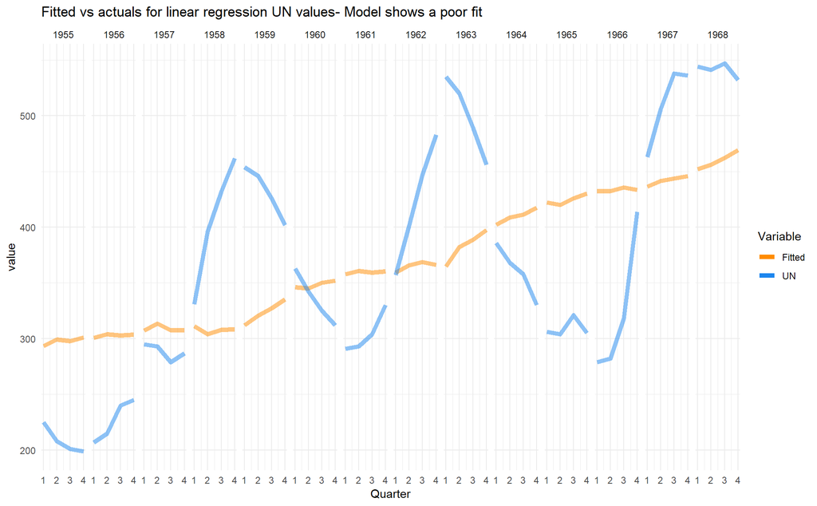

```r
lm_train %>%
  select(Year, Quarter, UN) %>%
  mutate(Fitted = un_lm$fitted) %>%
  gather(key = "Variable", value = "value", -Year, -Quarter) %>%
  ggplot(aes(Quarter, value, colour = Variable)) +
  geom_line(size = 2, alpha = .5) +
  facet_wrap(facets = "Year", nrow = 1) +
  scale_colour_manual(values = c("darkorange", "dodgerblue2")) +
  guides(colour = guide_legend(override.aes = list(alpha = 1))) +
  ggtitle("Fitted vs actuals for linear regression UN values- Model shows a poor fit")
```

This poor fit is further seen in the percentage miss plot. There is a wide range of misses that range from about -55% to 35%, both of which are substantially off. This really highlights how poor the fitted values are. The plot highlights how much better the ARIMA model picks up the cyclical nature of the unemployment numbers. Linear regression by definition picks up the upward trend here but, has no way of accounting for the varied unemployment cycles.

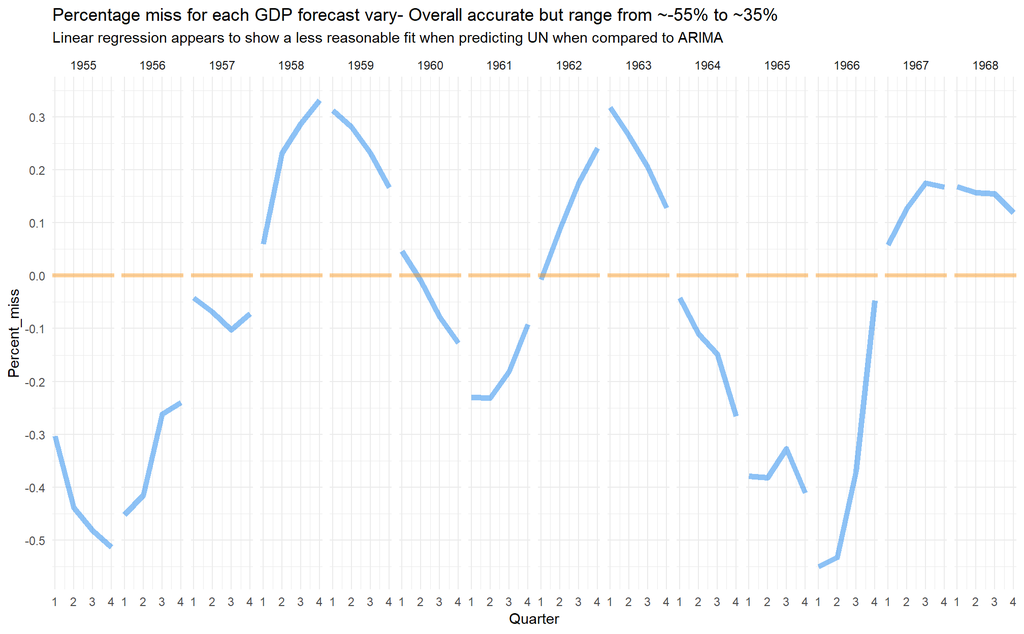

```r
lm_train %>%
  mutate(fitted = un_lm$fitted,
         Percent_miss = (UN - fitted) / UN) %>%
  ggplot(aes(Quarter, Percent_miss)) +
  geom_line(size = 2, alpha = .5, colour = "dodgerblue2") +
  geom_hline(yintercept = 0, size = 1.5, alpha = .4, colour = "darkorange") +
  facet_wrap(facets = "Year", nrow = 1) +
  scale_y_continuous(breaks = seq(-1, 1, .1)) +
  labs(title = "Percentage miss for each GDP forecast vary- Overall accurate but range from ~-55% to ~35%",
       subtitle = "Linear regression appears to show a less reasonable fit when predicting UN when compared to ARIMA")
```

Since the model showed high variance between the fitted and actuals, I wanted to look at the residual plot as well. The output shows clear signs of heteroskedasticity with uneven residuals. This means the model isn’t capturing some underlying pattern, which was evident in previous plots. As a result, the predictions vary and are unequal across the time series.

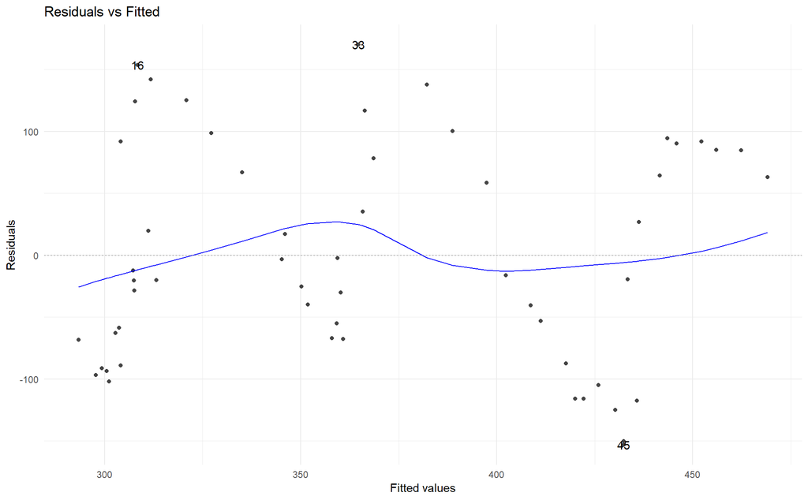

```r
autoplot(un_lm, which = 1)
```

To finalize this component, I’ve put together the 1969 predictions for unemployment. The percentage misses seems slightly lower than the training values and range from about 9.6% to about 13.2%.

```r
(un_test <- lm_test %>%
  select(-GDP) %>%
  mutate(prediction = predict(un_lm, lm_test),
         residual = UN - prediction,
         percent_miss = round(residual / UN, 3)))
```

```
##   Year Quarter  UN prediction residual percent_miss
## 1 1969       1 532   464.2380 67.76199        0.127
## 2 1969       2 519   469.0615 49.93849        0.096
## 3 1969       3 547   474.8497 72.15029        0.132
## 4 1969       4 544   477.7438 66.25619        0.122
```

The accuracy metrics still show a poor fit but, they are better than training. Again, this is likely because of the cyclical unemployment numbers; in 1969 the values are in a cyclical stage where they are coming back down and therefore, happen to coincide with the broad upward trend from the model. Still, the model is fundamentally flawed and violates some of the assumptions of linear regression making it untenable as a forecasting choice.

```r
c(Train_SSE = sum(un_lm$residuals ^ 2),
  Train_MSE = mean(un_lm$residuals ^ 2),
  Train_RMSE = sqrt(mean(un_lm$residuals ^ 2)),
  Test_SSE = sum(un_lm$residuals ^ 2),
  Test_MSE = mean(un_test$residual ^ 2),
  Test_RMSE = sqrt(mean(un_test$residual ^ 2)))
```

```
##    Train_SSE    Train_MSE   Train_RMSE     Test_SSE     Test_MSE
## 429929.48110   7677.31216     87.62027 429929.48110   4170.27150
##    Test_RMSE
##     64.57764
```

When comparing both the GDP and unemployment models, my guess would be GDP is the more appropriate dependent. It has much more accurate and stable predictions owing to an underlying pattern that is suitable for the linear regression model. A stable, positive trend can be modelled using OLS regression whereas a non-linear, cyclical trend is not well suited for the method.

That said, there needs to be more outside context to decide which variable is ideally situated to be the outcome here. Situtationally, it might make sense to make either a dependent or predictor given a project’s focus. Therefore, their respective coefficients and linear summaries do not inherently lend signs as to which one should normatively be the dependent variable. Overall though, the unemployment numbers display a structure that is not sutiable for a simple linear regression model making the GDP a more reasonable choice here.